# importing all packages and set plots to be embedded inline

```python
import numpy as np
import pandas as pd
import matplotlib.pyplot as plt
import seaborn as sb

%matplotlib inline
```

In this slide presentation. Many insights will be visualized on (Ford GoBike and baywheels bike for 2019. The visualization will be in three sections. Univariate, exploring one variable and its distribution. Bivariate, exploring two Variables and the correlation between them and multivariate exploring the relationship between three variables.

# The Data

## Each trip is anonymized and includes:

- **Trip Duration**
- **Start Time and Date**
- **End Time and Date**
- **Start Station ID**
- **Start Station Name**
- **Start Station Latitude**
- **Start Station Longitude**
- **End Station ID**
- **End Station Name**
- **End Station Latitude**
- **End Station Longitude**
- **Bike ID**
- **Bike Share for All Trip**

  > which tracks members who are enrolled in the Bike Share for All program for low-income residents.
- **User Type**

  > (Subscriber or Customer – “Subscriber” = Member or “Customer” = Casual)

```python
df=pd.read_csv("cleaned_combined.csv",parse_dates=["start_time","end_time"])
#The data is already cleaned from the fist file
df.head()#reading first 5 rows
```

|  | duration_min | day | start_time | end_time | distance_km | start_station_id | start_station_name | start_station_latitude | start_station_longitude | end_station_id | end_station_name | end_station_latitude | end_station_longitude | user_type | bike_share_for_all_trip | month |
| --- | --- | --- | --- | --- | --- | --- | --- | --- | --- | --- | --- | --- | --- | --- | --- | --- |
| 0 | 600.316667 | Monday | 2019-09-30 16:16:32.353 | 2019-10-01 02:16:51.982 | 1.045756 | 294.0 | Pierce Ave at Market St | 37.327581 | -121.884559 | 443.0 | 3rd St at Keyes St | 37.320866 | -121.876279 | Customer | False | 9 |
| 1 | 93.583333 | Monday | 2019-09-30 23:12:25.998 | 2019-10-01 00:46:01.959 | 0.415781 | 370.0 | Jones St at Post St | 37.787327 | -122.413278 | 4.0 | Cyril Magnin St at Ellis St | 37.785881 | -122.408915 | Customer | False | 9 |
| 2 | 24.700000 | Monday | 2019-09-30 23:57:34.663 | 2019-10-01 00:22:16.849 | 3.192105 | 109.0 | 17th St at Valencia St | 37.763316 | -122.421904 | 460.0 | Terry Francois Blvd at Warriors Way | 37.769095 | -122.386333 | Customer | False | 9 |
| 3 | 21.200000 | Monday | 2019-09-30 23:53:28.653 | 2019-10-01 00:14:41.074 | 1.377103 | 95.0 | Sanchez St at 15th St | 37.766219 | -122.431060 | 127.0 | Valencia St at 21st St | 37.756708 | -122.421025 | Subscriber | False | 9 |
| 4 | 144.133333 | Monday | 2019-09-30 21:43:51.014 | 2019-10-01 00:07:59.893 | 1.339155 | 11.0 | Davis St at Jackson St | 37.797280 | -122.398436 | 3.0 | Powell St BART Station (Market St at 4th St) | 37.786375 | -122.404904 | Customer | False | 9 |

```python
df.info(verbose=True,null_counts=True)#Viewing Dtype and check for NaN
```

```
<class 'pandas.core.frame.DataFrame'>
RangeIndex: 2207546 entries, 0 to 2207545
Data columns (total 16 columns):
 #   Column                   Non-Null Count    Dtype
---  ------                   --------------    -----
 0   duration_min             2207546 non-null  float64
 1   day                      2207546 non-null  object
 2   start_time               2207546 non-null  datetime64[ns]
 3   end_time                 2207546 non-null  datetime64[ns]
 4   distance_km              2207546 non-null  float64
 5   start_station_id         2207546 non-null  float64
 6   start_station_name       2207546 non-null  object
 7   start_station_latitude   2207546 non-null  float64
 8   start_station_longitude  2207546 non-null  float64
 9   end_station_id           2207546 non-null  float64
 10  end_station_name         2207546 non-null  object
 11  end_station_latitude     2207546 non-null  float64
 12  end_station_longitude    2207546 non-null  float64
 13  user_type                2207546 non-null  object
 14  bike_share_for_all_trip  2207546 non-null  bool
 15  month                    2207546 non-null  int64
dtypes: bool(1), datetime64[ns](2), float64(8), int64(1), object(4)
memory usage: 254.7+ MB
```

# Now we have stored our data into a DataFrame lets start visualization.

# Univariate visualization.

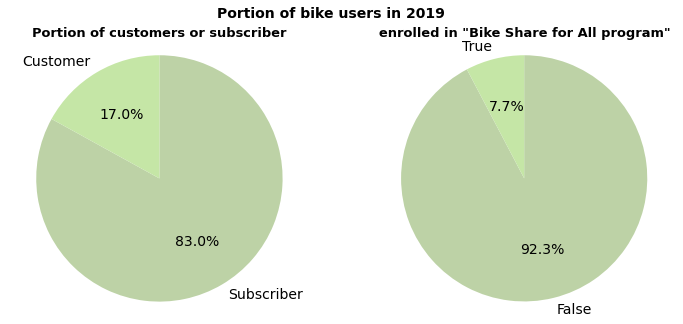

```python
#create figure and axes object and setting number of columns of subplit grid
fig,(ax1,ax2)=plt.subplots(figsize=(12,5),ncols=2)
colors=["#BDD2A6","#C5E6A6"]
fig.suptitle('Portion of bike users in 2019', fontsize=14, fontweight='bold')
user_type=df.user_type.value_counts()
bike_sh=df.bike_share_for_all_trip.value_counts()
# first axes plotting Portion of user_type
_=ax1.pie(user_type,labels=user_type.index,startangle=90,counterclock=False,
       wedgeprops={'width':1},autopct='%1.1f%%',textprops={'fontsize': 14},
         colors=colors)
_=ax1.set_title("Portion of customers or subscriber",size=13,fontweight='bold')
# Equal aspect ratio ensures that pie is drawn as a circle
_=ax1.axis('equal')

# Second  axes plotting Portion of bike_sh
_=ax2.pie(bike_sh,labels=bike_sh.index,startangle=90,counterclock=False,
         wedgeprops={'width':1},autopct='%1.1f%%',textprops={'fontsize': 14},
          colors=colors)
_=ax2.set_title("enrolled in \"Bike Share for All program\""
               ,size=13,fontweight='bold')
# Equal aspect ratio ensures that pie is drawn as a circle
_=ax2.axis('equal')
```

## Observation:

### Right pie chart:

This pie chart shows the portion of users enrolled in "Bike Share for All Program" and the majority in the dataset are not. Bike Share for All is available to Bay Area residents ages 18 and older who qualify for Calfresh, SFMTA Lifeline Pass, or PG&E CARE utility discount.

### Left pie chart:

This pie chart shows the portion of bike users wether They're a cCustomers or subscribers, the pie chart indicates that the majority are subscribed. The reason for that Probably because the fact that single rides start at \$2 for the first 30 minutes, then \\$2 per additional 15 minutes for the casual users whereas an annual membership has unlimited 45-minute Classic bike rides and discounted ebikes: Free unlocks and $0.15 per minute (waived if no Classic bikes available)

**Resource:** https://www.lyft.com/bikes/bay-wheels/bike-share-for-all

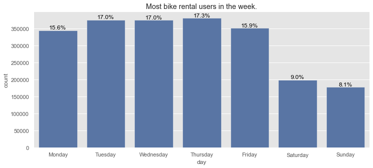

```python
#create the plot
sb.set(rc={'figure.figsize':(12,5)})
dayofweek=['Monday', 'Tuesday','Wednesday','Thursday'\
 ,'Friday','Saturday', 'Sunday']
color=sb.color_palette()[0]
with plt.style.context('ggplot'):
    sb.countplot(data=df,x="day", color= color,order=dayofweek)
    plt.title("Most bike rental users in the week.")

    #add annotations
    n_points=df.shape[0]
    day_counts=df['day'].value_counts()
    locs,labels=plt.xticks()#get the current tick locations and labels

    #loop thru each pair of locations nd labels
    for loc,label in zip(locs,labels):

        #get the text property for the label to get the correct count
        count=day_counts[label.get_text()]
        pct_string='{:0.1f}%'.format(100*count/n_points)

        # print the annotation at the top of the bar
        plt.text(loc,count-8,pct_string,ha='center',color='black',va='bottom',fontsize=12)
```

## Observation:

The majority of bike ride are in the weekdays mostly Thursday 17.3% whereas on Saturday 9% and Sunday 8.1% as we can see a major drop of bike ride users.

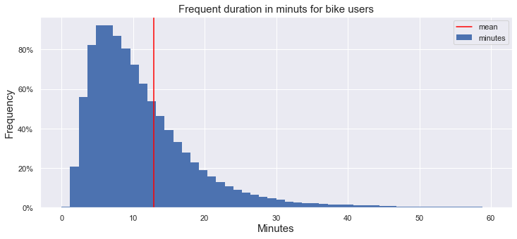

```python
from matplotlib.ticker import PercentFormatter
weights=np.ones(df.shape[0])/df.shape[0]

_=plt.hist(x=df.duration_min,lw=0,bins=50,range=(0,60),weights=weights)
_=plt.axvline(x=(df.duration_min).mean(),color='red')
plt.gca().yaxis.set_major_formatter(PercentFormatter(.1))
_=plt.title("Frequent duration in minuts for bike users",size=15)
_=plt.ylabel("Frequency",size=15)
_=plt.xlabel("Minutes",size=15)
_=plt.legend(["mean","minutes"])
```

## Observation:

Here is a right skewed distribution of duration in minutes for our data (aka positively skewd distribution). The majority falls between 3 and 7 minuts bike rids.

We have a mean of mean:12.8 and median:9.4 which is lower than the mean.

The reason that most bike users are below 60 is probably because bay-wheels bike share charges for rides longer than 60 minutes for $3 in each additional 15 minutes.

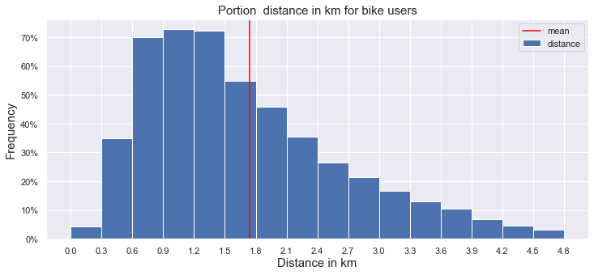

```python
weights=np.ones(df.shape[0])/df.shape[0]

_=plt.hist(df.distance_km,bins=np.arange(0,5,.3),range=None,weights=weights,lw=1)
plt.gca().yaxis.set_major_formatter(PercentFormatter(.2))
_=plt.axvline(x=df.distance_km.mean(),color='red')
_=plt.title("Portion  distance in km for bike users",size=15)
_=plt.ylabel("Frequency",size=15)
_=plt.xlabel("Distance in km",size=15)
_=plt.xticks(np.arange(0,5,.3))
_=plt.legend(["mean","distance"])
```

## Observation:

# Bivariate visualization.

## Exploring distribution of the dataset and variables using heatmap.

we will explore selected variable and try to see the correlation between each one using visualization.

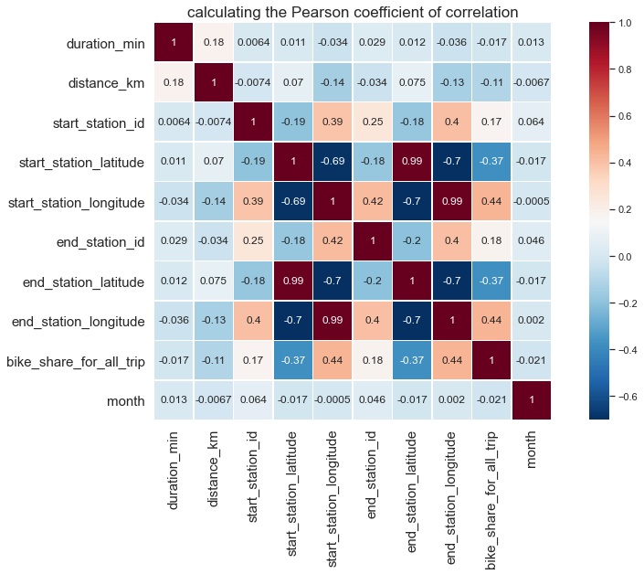

```python
pearsoncorr=df.copy()
pearsoncorr=pearsoncorr.corr(method='pearson')#new data frame that holds the pearson correlation
plt.figure(figsize=(15,8))#create a figure object
_=sb.heatmap(pearsoncorr,cmap='RdBu_r',
           annot=True,annot_kws={'size':12},
           linewidth=0.5,square=True)#visualization

plt.xticks(size=15);plt.yticks(size=15)#setting x & y tick size
_=plt.title("calculating the Pearson coefficient of correlation",size=17)# creating title
```

# Observation:

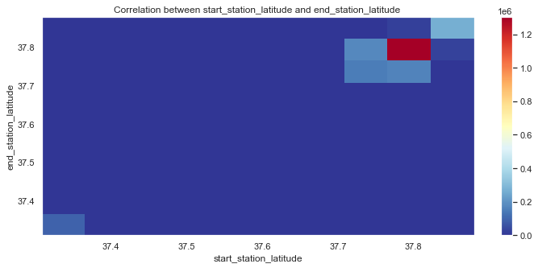

```python
from matplotlib.colors import LogNorm
fig, ax = plt.subplots()#create figure and axis for the plot
# create 2d hist for start station latitude in the x axis and end station latitude in the y axis
h=ax.hist2d(x=df.start_station_latitude,y=df.end_station_latitude,cmap=plt.cm.RdYlBu_r)
plt.colorbar(mappable=h[3],ax=ax)
plt.title("Correlation between start_station_latitude and end_station_latitude ")
plt.ylabel("end_station_latitude")
plt.xlabel("start_station_latitude")
# h[3]-> get the image from the return value so it knows what colormap and limits for colorbar
```

There is a positive correlation between the start and end latitude as we can see from the visualization.

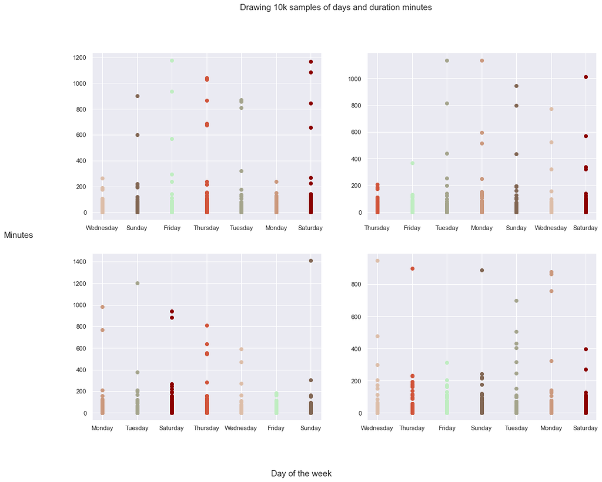

```python
fig,ax=plt.subplots(ncols=2,nrows=2,figsize=(16,12))#create 4 figures
#rows,columns and inter these are to iterate over each figure
rows=[0,1,0,1]
columns=[0,0,1,1]
inter=list(zip(rows,columns))
'''the below nested for loop will iterate over each axis of the figure
and draw a random 10k sample of duration and day '''
for j in range(len(inter)):# This will loop 4 times
    sam=df.sample(10_000)#set 10k sample df each loop
    for i in sam.index:#calculate days and duration for each figure
        if (sam['day'][i]=='Monday'):
            ax[inter[j]].scatter(sam['day'][i],sam['duration_min'][i],color='#CB997E',label='Monday')
        elif (sam['day'][i]=='Sunday'):
            ax[inter[j]].scatter(sam['day'][i],sam['duration_min'][i],color='#826754',label='Sunday')
        elif (sam['day'][i]=='Saturday'):
            ax[inter[j]].scatter(sam['day'][i],sam['duration_min'][i],color='#8B0000',label='Saturday')
        elif (sam['day'][i]=='Friday'):
            ax[inter[j]].scatter(sam['day'][i],sam['duration_min'][i],color='#BFEDC1',label='Friday')
        elif (sam['day'][i]=='Thursday'):
            ax[inter[j]].scatter(sam['day'][i],sam['duration_min'][i],color='#D1553B',label='Thursday')
        elif (sam['day'][i]=='Wednesday'):
            ax[inter[j]].scatter(sam['day'][i],sam['duration_min'][i],color='#DDBEA9',label='Wednesday')
        elif (sam['day'][i]=='Tuesday'):
            ax[inter[j]].scatter(sam['day'][i],sam['duration_min'][i],color='#A5A58D',label='Tuesday')

# lines_labels = [ax.get_legend_handles_labels() for ax in fig.axes]
# lines, labels = [sum(lol, []) for lol in zip(*lines_labels)]
# fig.legend(lines, labels)

fig.suptitle("Drawing 10k samples of days and duration minutes",fontsize=15)#title
fig.text(-.01,.5,'Minutes',fontsize=15)#y label position
fig.text(.4,.01,'Day of the week',fontsize=15)# xlabel position
plt.show()#this will remove unwanted text
#plt.savefig("day_duration.png")
```

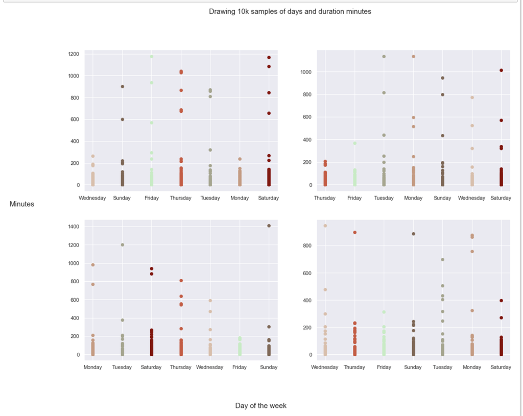

```python
# display the plot
from IPython.display import Image
Image (filename="day_duration.png")
```